# Insurance Fraud Detection - Revisited

Necessary imports

```python
import  pandas as pd
import numpy as np
import missingno as msno

import matplotlib.pyplot as plt
import seaborn as sns
import plotly.express as px

import warnings
warnings.filterwarnings('ignore')
plt.style.use('ggplot')
```

Loading dataset

```python
dataset = pd.read_csv("insurance_claims.csv")
```

## 1.0 Exploratory Data Analysis

### 1.1 Exploring

```python
dataset.head(10)
```

|  | months_as_customer | age | policy_number | policy_bind_date | policy_state | policy_csl | policy_deductable | policy_annual_premium | umbrella_limit | insured_zip | ... | police_report_available | total_claim_amount | injury_claim | property_claim | vehicle_claim | auto_make | auto_model | auto_year | fraud_reported | _c39 |
| --- | --- | --- | --- | --- | --- | --- | --- | --- | --- | --- | --- | --- | --- | --- | --- | --- | --- | --- | --- | --- | --- |
| 0 | 328 | 48 | 521585 | 2014-10-17 | OH | 250/500 | 1000 | 1406.91 | 0 | 466132 | ... | YES | 71610 | 6510 | 13020 | 52080 | Saab | 92x | 2004 | Y | NaN |
| 1 | 228 | 42 | 342868 | 2006-06-27 | IN | 250/500 | 2000 | 1197.22 | 5000000 | 468176 | ... | ? | 5070 | 780 | 780 | 3510 | Mercedes | E400 | 2007 | Y | NaN |
| 2 | 134 | 29 | 687698 | 2000-09-06 | OH | 100/300 | 2000 | 1413.14 | 5000000 | 430632 | ... | NO | 34650 | 7700 | 3850 | 23100 | Dodge | RAM | 2007 | N | NaN |
| 3 | 256 | 41 | 227811 | 1990-05-25 | IL | 250/500 | 2000 | 1415.74 | 6000000 | 608117 | ... | NO | 63400 | 6340 | 6340 | 50720 | Chevrolet | Tahoe | 2014 | Y | NaN |
| 4 | 228 | 44 | 367455 | 2014-06-06 | IL | 500/1000 | 1000 | 1583.91 | 6000000 | 610706 | ... | NO | 6500 | 1300 | 650 | 4550 | Accura | RSX | 2009 | N | NaN |
| 5 | 256 | 39 | 104594 | 2006-10-12 | OH | 250/500 | 1000 | 1351.10 | 0 | 478456 | ... | NO | 64100 | 6410 | 6410 | 51280 | Saab | 95 | 2003 | Y | NaN |
| 6 | 137 | 34 | 413978 | 2000-06-04 | IN | 250/500 | 1000 | 1333.35 | 0 | 441716 | ... | ? | 78650 | 21450 | 7150 | 50050 | Nissan | Pathfinder | 2012 | N | NaN |
| 7 | 165 | 37 | 429027 | 1990-02-03 | IL | 100/300 | 1000 | 1137.03 | 0 | 603195 | ... | YES | 51590 | 9380 | 9380 | 32830 | Audi | A5 | 2015 | N | NaN |
| 8 | 27 | 33 | 485665 | 1997-02-05 | IL | 100/300 | 500 | 1442.99 | 0 | 601734 | ... | YES | 27700 | 2770 | 2770 | 22160 | Toyota | Camry | 2012 | N | NaN |
| 9 | 212 | 42 | 636550 | 2011-07-25 | IL | 100/300 | 500 | 1315.68 | 0 | 600983 | ... | ? | 42300 | 4700 | 4700 | 32900 | Saab | 92x | 1996 | N | NaN |

10 rows × 40 columns

From the dataset, we can clearly see that we have '?'s. We need to replace them with NaN

```python
dataset.replace('?', np.nan, inplace = True )
```

Confirm that it has been eliminated

```python
dataset.head(10)
```

|  | months_as_customer | age | policy_number | policy_bind_date | policy_state | policy_csl | policy_deductable | policy_annual_premium | umbrella_limit | insured_zip | ... | police_report_available | total_claim_amount | injury_claim | property_claim | vehicle_claim | auto_make | auto_model | auto_year | fraud_reported | _c39 |
| --- | --- | --- | --- | --- | --- | --- | --- | --- | --- | --- | --- | --- | --- | --- | --- | --- | --- | --- | --- | --- | --- |
| 0 | 328 | 48 | 521585 | 2014-10-17 | OH | 250/500 | 1000 | 1406.91 | 0 | 466132 | ... | YES | 71610 | 6510 | 13020 | 52080 | Saab | 92x | 2004 | Y | NaN |
| 1 | 228 | 42 | 342868 | 2006-06-27 | IN | 250/500 | 2000 | 1197.22 | 5000000 | 468176 | ... | NaN | 5070 | 780 | 780 | 3510 | Mercedes | E400 | 2007 | Y | NaN |
| 2 | 134 | 29 | 687698 | 2000-09-06 | OH | 100/300 | 2000 | 1413.14 | 5000000 | 430632 | ... | NO | 34650 | 7700 | 3850 | 23100 | Dodge | RAM | 2007 | N | NaN |
| 3 | 256 | 41 | 227811 | 1990-05-25 | IL | 250/500 | 2000 | 1415.74 | 6000000 | 608117 | ... | NO | 63400 | 6340 | 6340 | 50720 | Chevrolet | Tahoe | 2014 | Y | NaN |
| 4 | 228 | 44 | 367455 | 2014-06-06 | IL | 500/1000 | 1000 | 1583.91 | 6000000 | 610706 | ... | NO | 6500 | 1300 | 650 | 4550 | Accura | RSX | 2009 | N | NaN |
| 5 | 256 | 39 | 104594 | 2006-10-12 | OH | 250/500 | 1000 | 1351.10 | 0 | 478456 | ... | NO | 64100 | 6410 | 6410 | 51280 | Saab | 95 | 2003 | Y | NaN |
| 6 | 137 | 34 | 413978 | 2000-06-04 | IN | 250/500 | 1000 | 1333.35 | 0 | 441716 | ... | NaN | 78650 | 21450 | 7150 | 50050 | Nissan | Pathfinder | 2012 | N | NaN |
| 7 | 165 | 37 | 429027 | 1990-02-03 | IL | 100/300 | 1000 | 1137.03 | 0 | 603195 | ... | YES | 51590 | 9380 | 9380 | 32830 | Audi | A5 | 2015 | N | NaN |
| 8 | 27 | 33 | 485665 | 1997-02-05 | IL | 100/300 | 500 | 1442.99 | 0 | 601734 | ... | YES | 27700 | 2770 | 2770 | 22160 | Toyota | Camry | 2012 | N | NaN |
| 9 | 212 | 42 | 636550 | 2011-07-25 | IL | 100/300 | 500 | 1315.68 | 0 | 600983 | ... | NaN | 42300 | 4700 | 4700 | 32900 | Saab | 92x | 1996 | N | NaN |

10 rows × 40 columns

Let's see the number of features in the dataset

```python
dataset.shape
```

```
(1000, 40)
```

```python
print(f"The dataset has {dataset.shape[1]} features & {dataset.shape[0]} samples. Here, machine learning would work well.")
```

```
The dataset has 40 features & 1000 samples. Here, machine learning would work well.
```

Descriptive statistics

```python
dataset.describe()
```

|  | months_as_customer | age | policy_number | policy_deductable | policy_annual_premium | umbrella_limit | insured_zip | capital-gains | capital-loss | incident_hour_of_the_day | number_of_vehicles_involved | bodily_injuries | witnesses | total_claim_amount | injury_claim | property_claim | vehicle_claim | auto_year | _c39 |
| --- | --- | --- | --- | --- | --- | --- | --- | --- | --- | --- | --- | --- | --- | --- | --- | --- | --- | --- | --- |
| count | 1000.000000 | 1000.000000 | 1000.000000 | 1000.000000 | 1000.000000 | 1.000000e+03 | 1000.000000 | 1000.000000 | 1000.000000 | 1000.000000 | 1000.00000 | 1000.000000 | 1000.000000 | 1000.00000 | 1000.000000 | 1000.000000 | 1000.000000 | 1000.000000 | 0.0 |
| mean | 203.954000 | 38.948000 | 546238.648000 | 1136.000000 | 1256.406150 | 1.101000e+06 | 501214.488000 | 25126.100000 | -26793.700000 | 11.644000 | 1.83900 | 0.992000 | 1.487000 | 52761.94000 | 7433.420000 | 7399.570000 | 37928.950000 | 2005.103000 | NaN |
| std | 115.113174 | 9.140287 | 257063.005276 | 611.864673 | 244.167395 | 2.297407e+06 | 71701.610941 | 27872.187708 | 28104.096686 | 6.951373 | 1.01888 | 0.820127 | 1.111335 | 26401.53319 | 4880.951853 | 4824.726179 | 18886.252893 | 6.015861 | NaN |
| min | 0.000000 | 19.000000 | 100804.000000 | 500.000000 | 433.330000 | -1.000000e+06 | 430104.000000 | 0.000000 | -111100.000000 | 0.000000 | 1.00000 | 0.000000 | 0.000000 | 100.00000 | 0.000000 | 0.000000 | 70.000000 | 1995.000000 | NaN |
| 25% | 115.750000 | 32.000000 | 335980.250000 | 500.000000 | 1089.607500 | 0.000000e+00 | 448404.500000 | 0.000000 | -51500.000000 | 6.000000 | 1.00000 | 0.000000 | 1.000000 | 41812.50000 | 4295.000000 | 4445.000000 | 30292.500000 | 2000.000000 | NaN |
| 50% | 199.500000 | 38.000000 | 533135.000000 | 1000.000000 | 1257.200000 | 0.000000e+00 | 466445.500000 | 0.000000 | -23250.000000 | 12.000000 | 1.00000 | 1.000000 | 1.000000 | 58055.00000 | 6775.000000 | 6750.000000 | 42100.000000 | 2005.000000 | NaN |
| 75% | 276.250000 | 44.000000 | 759099.750000 | 2000.000000 | 1415.695000 | 0.000000e+00 | 603251.000000 | 51025.000000 | 0.000000 | 17.000000 | 3.00000 | 2.000000 | 2.000000 | 70592.50000 | 11305.000000 | 10885.000000 | 50822.500000 | 2010.000000 | NaN |
| max | 479.000000 | 64.000000 | 999435.000000 | 2000.000000 | 2047.590000 | 1.000000e+07 | 620962.000000 | 100500.000000 | 0.000000 | 23.000000 | 4.00000 | 2.000000 | 3.000000 | 114920.00000 | 21450.000000 | 23670.000000 | 79560.000000 | 2015.000000 | NaN |

```python
dataset.describe(include = 'all')
```

|  | months_as_customer | age | policy_number | policy_bind_date | policy_state | policy_csl | policy_deductable | policy_annual_premium | umbrella_limit | insured_zip | ... | police_report_available | total_claim_amount | injury_claim | property_claim | vehicle_claim | auto_make | auto_model | auto_year | fraud_reported | _c39 |
| --- | --- | --- | --- | --- | --- | --- | --- | --- | --- | --- | --- | --- | --- | --- | --- | --- | --- | --- | --- | --- | --- |
| count | 1000.000000 | 1000.000000 | 1000.000000 | 1000 | 1000 | 1000 | 1000.000000 | 1000.000000 | 1.000000e+03 | 1000.000000 | ... | 657 | 1000.00000 | 1000.000000 | 1000.000000 | 1000.000000 | 1000 | 1000 | 1000.000000 | 1000 | 0.0 |
| unique | NaN | NaN | NaN | 951 | 3 | 3 | NaN | NaN | NaN | NaN | ... | 2 | NaN | NaN | NaN | NaN | 14 | 39 | NaN | 2 | NaN |
| top | NaN | NaN | NaN | 2006-01-01 | OH | 250/500 | NaN | NaN | NaN | NaN | ... | NO | NaN | NaN | NaN | NaN | Saab | RAM | NaN | N | NaN |
| freq | NaN | NaN | NaN | 3 | 352 | 351 | NaN | NaN | NaN | NaN | ... | 343 | NaN | NaN | NaN | NaN | 80 | 43 | NaN | 753 | NaN |
| mean | 203.954000 | 38.948000 | 546238.648000 | NaN | NaN | NaN | 1136.000000 | 1256.406150 | 1.101000e+06 | 501214.488000 | ... | NaN | 52761.94000 | 7433.420000 | 7399.570000 | 37928.950000 | NaN | NaN | 2005.103000 | NaN | NaN |
| std | 115.113174 | 9.140287 | 257063.005276 | NaN | NaN | NaN | 611.864673 | 244.167395 | 2.297407e+06 | 71701.610941 | ... | NaN | 26401.53319 | 4880.951853 | 4824.726179 | 18886.252893 | NaN | NaN | 6.015861 | NaN | NaN |
| min | 0.000000 | 19.000000 | 100804.000000 | NaN | NaN | NaN | 500.000000 | 433.330000 | -1.000000e+06 | 430104.000000 | ... | NaN | 100.00000 | 0.000000 | 0.000000 | 70.000000 | NaN | NaN | 1995.000000 | NaN | NaN |
| 25% | 115.750000 | 32.000000 | 335980.250000 | NaN | NaN | NaN | 500.000000 | 1089.607500 | 0.000000e+00 | 448404.500000 | ... | NaN | 41812.50000 | 4295.000000 | 4445.000000 | 30292.500000 | NaN | NaN | 2000.000000 | NaN | NaN |
| 50% | 199.500000 | 38.000000 | 533135.000000 | NaN | NaN | NaN | 1000.000000 | 1257.200000 | 0.000000e+00 | 466445.500000 | ... | NaN | 58055.00000 | 6775.000000 | 6750.000000 | 42100.000000 | NaN | NaN | 2005.000000 | NaN | NaN |
| 75% | 276.250000 | 44.000000 | 759099.750000 | NaN | NaN | NaN | 2000.000000 | 1415.695000 | 0.000000e+00 | 603251.000000 | ... | NaN | 70592.50000 | 11305.000000 | 10885.000000 | 50822.500000 | NaN | NaN | 2010.000000 | NaN | NaN |
| max | 479.000000 | 64.000000 | 999435.000000 | NaN | NaN | NaN | 2000.000000 | 2047.590000 | 1.000000e+07 | 620962.000000 | ... | NaN | 114920.00000 | 21450.000000 | 23670.000000 | 79560.000000 | NaN | NaN | 2015.000000 | NaN | NaN |

11 rows × 40 columns

```python
dataset.info()
```

```
<class 'pandas.core.frame.DataFrame'>
RangeIndex: 1000 entries, 0 to 999
Data columns (total 40 columns):
 #   Column                       Non-Null Count  Dtype
---  ------                       --------------  -----
 0   months_as_customer           1000 non-null   int64
 1   age                          1000 non-null   int64
 2   policy_number                1000 non-null   int64
 3   policy_bind_date             1000 non-null   object
 4   policy_state                 1000 non-null   object
 5   policy_csl                   1000 non-null   object
 6   policy_deductable            1000 non-null   int64
 7   policy_annual_premium        1000 non-null   float64
 8   umbrella_limit               1000 non-null   int64
 9   insured_zip                  1000 non-null   int64
```

[output cut: 32 more lines]

Missing values. We get to see that there are some.

```python
dataset.isnull().sum()
```

```
months_as_customer                0
age                               0
policy_number                     0
policy_bind_date                  0
policy_state                      0
policy_csl                        0
policy_deductable                 0
policy_annual_premium             0
umbrella_limit                    0
insured_zip                       0
insured_sex                       0
insured_education_level           0
insured_occupation                0
insured_hobbies                   0
insured_relationship              0
capital-gains                     0
capital-loss                      0
incident_date                     0
incident_type                     0
collision_type                  178
incident_severity                 0
authorities_contacted             0
incident_state                    0
incident_city                     0
incident_location                 0
incident_hour_of_the_day          0
number_of_vehicles_involved       0
property_damage                 360
bodily_injuries                   0
witnesses                         0
police_report_available         343
total_claim_amount                0
injury_claim                      0
property_claim                    0
vehicle_claim                     0
auto_make                         0
auto_model                        0
auto_year                         0
fraud_reported                    0
_c39                           1000
dtype: int64
```

Heatmap

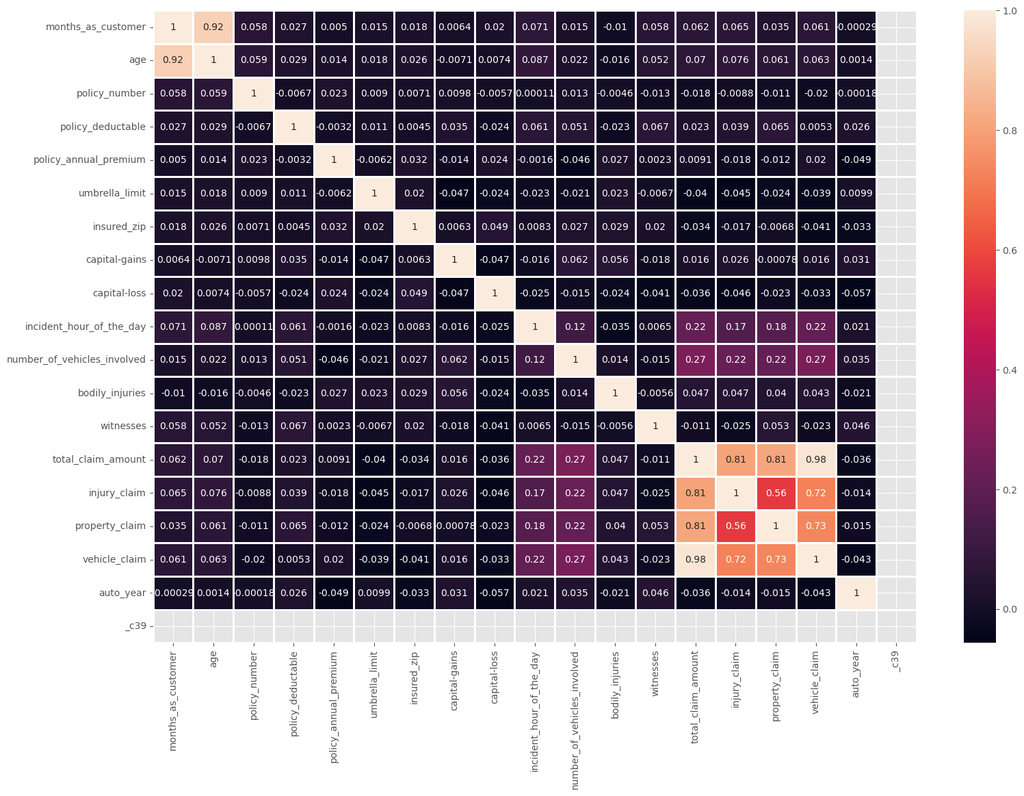

```python
plt.figure(figsize = (18, 12))

corr = dataset.corr()

sns.heatmap(data = corr, annot = True, fmt = '0.2g', linewidth = 1)

plt.show()
```

Checking for multicollinearity

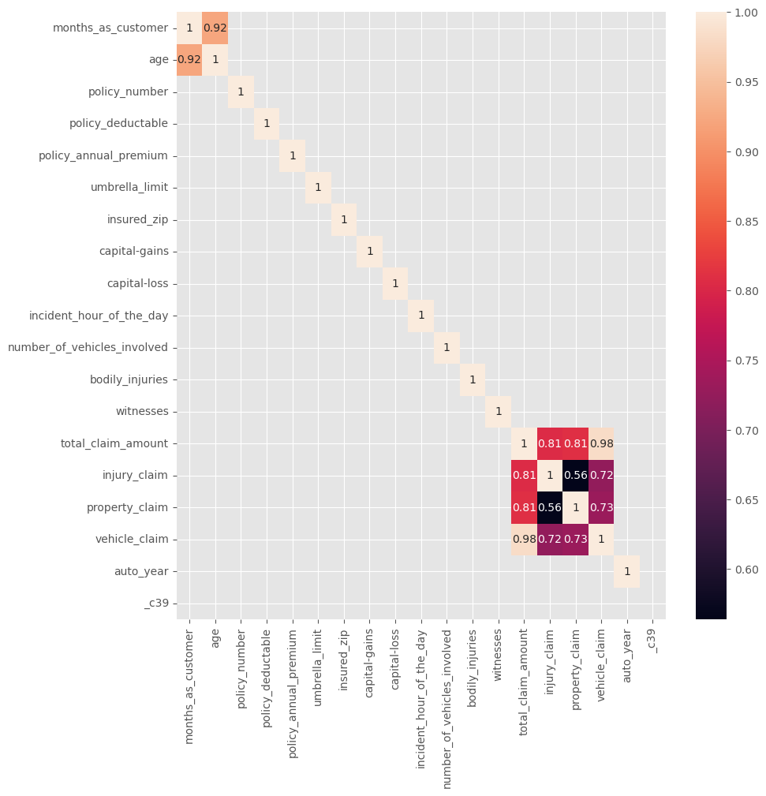

```python
plt.figure(figsize = (10, 10))
sns.heatmap(corr[(corr > 0.3) | (corr  < -0.3)], annot = True, fmt = '0.2g')
plt.show()
```

Confirming multicollinearlity

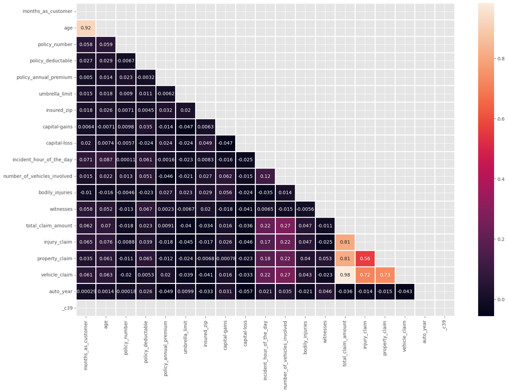

```python
plt.figure(figsize = (18, 12))
corr = dataset.corr()

mask = np.triu(np.ones_like(corr, dtype = bool))

sns.heatmap(data = corr, mask = mask, annot = True, fmt = '0.2g', linewidth = 1)
plt.show()
```

#### NB: We have all values with low correlation, except months_as_customer & age, vehicle_claim & total_claim_amount, injury_claim & vehicle_claim, property_claim and vehicle_claim, property_claim & injury_claim, total_claim_amount & injury_claim.

#### We remove total_claim_amount & months_as_customer.

```python
dataset.info()
```

```
<class 'pandas.core.frame.DataFrame'>
RangeIndex: 1000 entries, 0 to 999
Data columns (total 40 columns):
 #   Column                       Non-Null Count  Dtype
---  ------                       --------------  -----
 0   months_as_customer           1000 non-null   int64
 1   age                          1000 non-null   int64
 2   policy_number                1000 non-null   int64
 3   policy_bind_date             1000 non-null   object
 4   policy_state                 1000 non-null   object
 5   policy_csl                   1000 non-null   object
 6   policy_deductable            1000 non-null   int64
 7   policy_annual_premium        1000 non-null   float64
 8   umbrella_limit               1000 non-null   int64
 9   insured_zip                  1000 non-null   int64
```

[output cut: 32 more lines]

```python
dataset.drop(['total_claim_amount', 'months_as_customer'], axis = 1, inplace = True)
```

```python
dataset.info()
```

```
<class 'pandas.core.frame.DataFrame'>
RangeIndex: 1000 entries, 0 to 999
Data columns (total 38 columns):
 #   Column                       Non-Null Count  Dtype
---  ------                       --------------  -----
 0   age                          1000 non-null   int64
 1   policy_number                1000 non-null   int64
 2   policy_bind_date             1000 non-null   object
 3   policy_state                 1000 non-null   object
 4   policy_csl                   1000 non-null   object
 5   policy_deductable            1000 non-null   int64
 6   policy_annual_premium        1000 non-null   float64
 7   umbrella_limit               1000 non-null   int64
 8   insured_zip                  1000 non-null   int64
 9   insured_sex                  1000 non-null   object
```

[output cut: 30 more lines]

Removal of total_claim_amount & months_as_customer confirmed.

The target is imbalanced

```python
dataset['fraud_reported'].value_counts()
```

```
N    753
Y    247
Name: fraud_reported, dtype: int64
```

Visualizing data imbalance

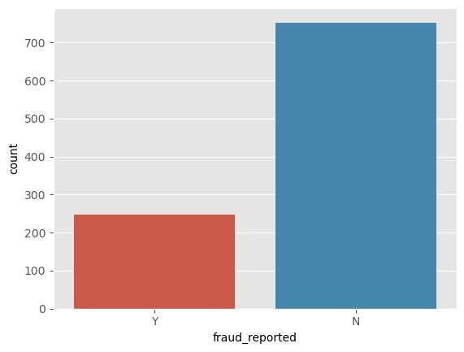

```python
sns.countplot(x=dataset['fraud_reported'])
plt.show()
```

Checking unique values of every feature/column

```python
dataset.nunique()
```

```
age                              46
policy_number                  1000
policy_bind_date                951
policy_state                      3
policy_csl                        3
policy_deductable                 3
policy_annual_premium           991
umbrella_limit                   11
insured_zip                     995
insured_sex                       2
insured_education_level           7
insured_occupation               14
insured_hobbies                  20
insured_relationship              6
capital-gains                   338
capital-loss                    354
incident_date                    60
incident_type                     4
collision_type                    3
incident_severity                 4
authorities_contacted             5
incident_state                    7
incident_city                     7
incident_location              1000
incident_hour_of_the_day         24
number_of_vehicles_involved       4
property_damage                   2
bodily_injuries                   3
witnesses                         4
police_report_available           2
injury_claim                    638
property_claim                  626
vehicle_claim                   726
auto_make                        14
auto_model                       39
auto_year                        21
fraud_reported                    2
_c39                              0
dtype: int64
```

### 1.2 Visualizing the distribution of the target variable

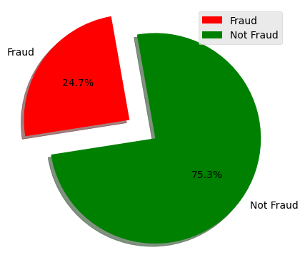

```python
fraud_state = ['Fraud', 'Not Fraud']

fraud_data = list()
fraud_reported = list(dataset["fraud_reported"]).count('Y')
fraud_data.append(fraud_reported)
fraud_data.append(dataset.shape[0] - fraud_reported)
fraud_data

mycolors = ('red', 'green')
myexplode = [0.3, 0.00]
plt.pie(fraud_data, labels = fraud_state, colors = mycolors, startangle = 100,
       explode = myexplode, shadow = True, autopct = '%1.1f%%')
plt.legend()
plt.show()
```

## 2.0 Data Pre-processing

### 2.1 Dropping columns/features that are not necessary for Predictions

```python
to_drop = ['policy_number', 'policy_bind_date', 'policy_state', 'insured_zip', 'incident_date',
           'incident_city', 'incident_location', 'incident_state', 'insured_hobbies', 'auto_make',
           'auto_model', 'auto_year', '_c39']
dataset.drop(to_drop, axis = 1, inplace = True)
dataset.shape
```

```
(1000, 25)
```

### 2.2 Detecting Missing Values Numerically

```python
# missing_values = dataset.isna().sum() # This code  detects missing values
missing_values = dataset.isnull().sum()
missing_values
```

```
age                              0
policy_csl                       0
policy_deductable                0
policy_annual_premium            0
umbrella_limit                   0
insured_sex                      0
insured_education_level          0
insured_occupation               0
insured_relationship             0
capital-gains                    0
capital-loss                     0
incident_type                    0
collision_type                 178
incident_severity                0
authorities_contacted            0
incident_hour_of_the_day         0
number_of_vehicles_involved      0
property_damage                360
bodily_injuries                  0
witnesses                        0
police_report_available        343
injury_claim                     0
property_claim                   0
vehicle_claim                    0
fraud_reported                   0
dtype: int64
```

#### We have missing values on features collision_type, property_damage & police_report_available

Missing values as a percentage of the entire dataset.

```python
percentage_missing_values = missing_values/dataset.shape[0]*100
print(f"{round(percentage_missing_values, 2)}")
```

```
age                             0.0
policy_csl                      0.0
policy_deductable               0.0
policy_annual_premium           0.0
umbrella_limit                  0.0
insured_sex                     0.0
insured_education_level         0.0
insured_occupation              0.0
insured_relationship            0.0
capital-gains                   0.0
capital-loss                    0.0
incident_type                   0.0
collision_type                 17.8
incident_severity               0.0
authorities_contacted           0.0
incident_hour_of_the_day        0.0
number_of_vehicles_involved     0.0
property_damage                36.0
bodily_injuries                 0.0
witnesses                       0.0
police_report_available        34.3
injury_claim                    0.0
property_claim                  0.0
vehicle_claim                   0.0
fraud_reported                  0.0
dtype: float64
```

### 2.3 Detecting Missing Values Visually using Missingno library

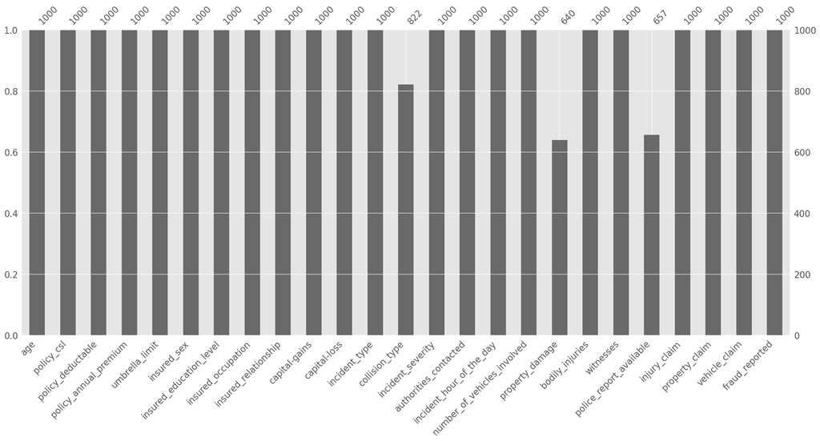

```python
msno.bar(dataset)
plt.show()
```

### 2.4 Visualizing location of the Missing Values

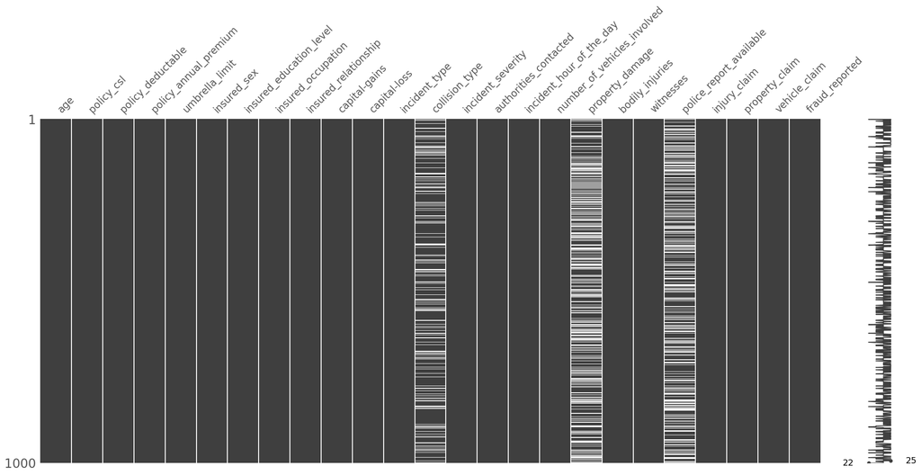

```python
msno.matrix(dataset)
plt.show()
```

The white lines show instances of missing values. It is possible to sample the dataset to pinpoint the exact location of the missing data. However, we can make a small sample of the same.

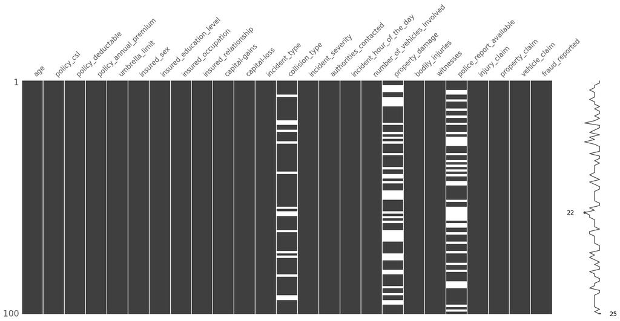

```python
msno.matrix(dataset.sample(100))
plt.show()
```

### 2.5 Finding reason for missing data using a Heatmap

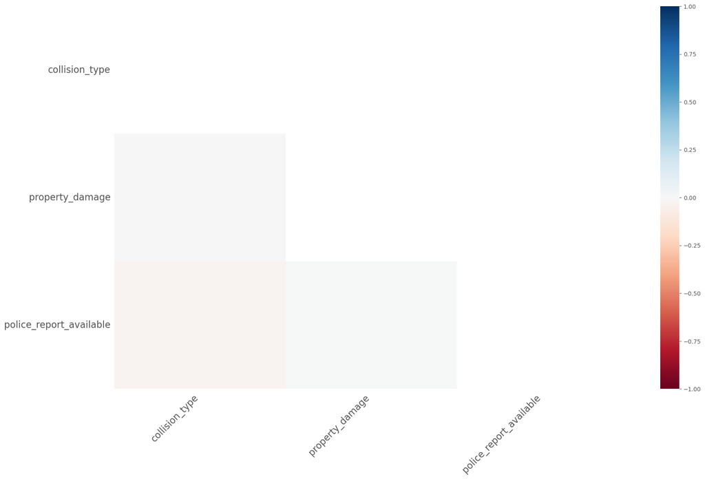

```python
msno.heatmap(dataset)
plt.show()
```

#### NB: Both visual and numerical test show the same missing values

### 2.6 Handling Missing Values

### 2.6.1 Replacing missing values with mode

```python
dataset.info()
```

```
<class 'pandas.core.frame.DataFrame'>
RangeIndex: 1000 entries, 0 to 999
Data columns (total 25 columns):
 #   Column                       Non-Null Count  Dtype
---  ------                       --------------  -----
 0   age                          1000 non-null   int64
 1   policy_csl                   1000 non-null   object
 2   policy_deductable            1000 non-null   int64
 3   policy_annual_premium        1000 non-null   float64
 4   umbrella_limit               1000 non-null   int64
 5   insured_sex                  1000 non-null   object
 6   insured_education_level      1000 non-null   object
 7   insured_occupation           1000 non-null   object
 8   insured_relationship         1000 non-null   object
 9   capital-gains                1000 non-null   int64
```

[output cut: 17 more lines]

#### Since all missing values are in categorical columna, we just replace them with mode

```python
dataset.isna().sum()
```

```
age                              0
policy_csl                       0
policy_deductable                0
policy_annual_premium            0
umbrella_limit                   0
insured_sex                      0
insured_education_level          0
insured_occupation               0
insured_relationship             0
capital-gains                    0
capital-loss                     0
incident_type                    0
collision_type                 178
incident_severity                0
authorities_contacted            0
incident_hour_of_the_day         0
number_of_vehicles_involved      0
property_damage                360
bodily_injuries                  0
witnesses                        0
police_report_available        343
injury_claim                     0
property_claim                   0
vehicle_claim                    0
fraud_reported                   0
dtype: int64
```

```python
for i in list(dataset.columns):
    dataset[i].fillna(dataset[i].mode()[0], inplace = True)
```

```python
dataset.isnull().sum()
```

```
age                            0
policy_csl                     0
policy_deductable              0
policy_annual_premium          0
umbrella_limit                 0
insured_sex                    0
insured_education_level        0
insured_occupation             0
insured_relationship           0
capital-gains                  0
capital-loss                   0
incident_type                  0
collision_type                 0
incident_severity              0
authorities_contacted          0
incident_hour_of_the_day       0
number_of_vehicles_involved    0
property_damage                0
bodily_injuries                0
witnesses                      0
police_report_available        0
injury_claim                   0
property_claim                 0
vehicle_claim                  0
fraud_reported                 0
dtype: int64
```

We've filled all the missing values

### 2.6.2 Outliers Detection

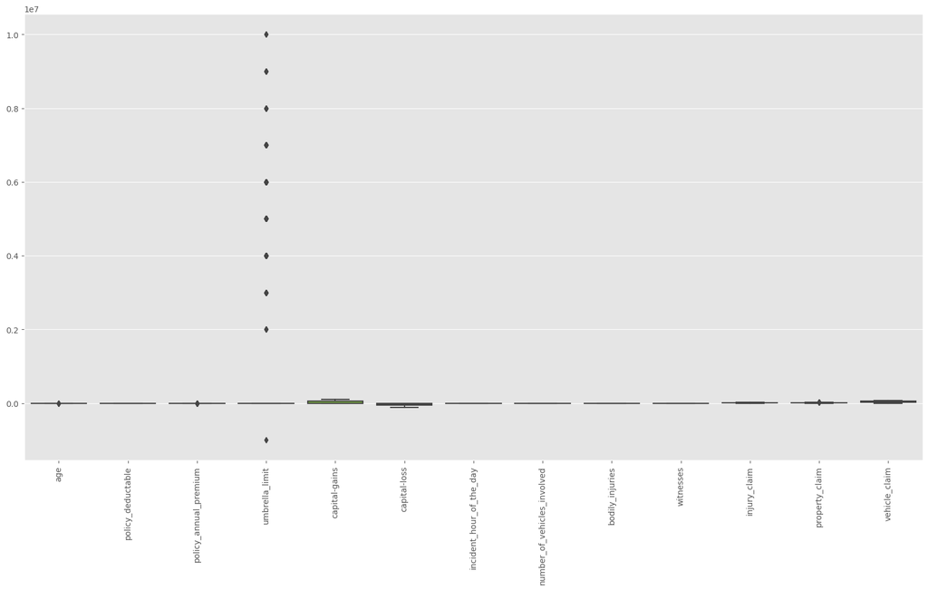

```python
plt.figure(figsize=(20,10))
sns.boxplot(dataset)
plt.xticks(rotation=90)
plt.show()
```

Outliers present

### 2.6.3 Dealing with numerical features/columns

```python
dataset_numerical = dataset.select_dtypes(include = ['float64', 'int64'])
dataset_numerical.head()
```

|  | age | policy_deductable | policy_annual_premium | umbrella_limit | capital-gains | capital-loss | incident_hour_of_the_day | number_of_vehicles_involved | bodily_injuries | witnesses | injury_claim | property_claim | vehicle_claim |
| --- | --- | --- | --- | --- | --- | --- | --- | --- | --- | --- | --- | --- | --- |
| 0 | 48 | 1000 | 1406.91 | 0 | 53300 | 0 | 5 | 1 | 1 | 2 | 6510 | 13020 | 52080 |
| 1 | 42 | 2000 | 1197.22 | 5000000 | 0 | 0 | 8 | 1 | 0 | 0 | 780 | 780 | 3510 |
| 2 | 29 | 2000 | 1413.14 | 5000000 | 35100 | 0 | 7 | 3 | 2 | 3 | 7700 | 3850 | 23100 |
| 3 | 41 | 2000 | 1415.74 | 6000000 | 48900 | -62400 | 5 | 1 | 1 | 2 | 6340 | 6340 | 50720 |
| 4 | 44 | 1000 | 1583.91 | 6000000 | 66000 | -46000 | 20 | 1 | 0 | 1 | 1300 | 650 | 4550 |

```python
dataset_numerical.isnull().sum()
```

```
age                            0
policy_deductable              0
policy_annual_premium          0
umbrella_limit                 0
capital-gains                  0
capital-loss                   0
incident_hour_of_the_day       0
number_of_vehicles_involved    0
bodily_injuries                0
witnesses                      0
injury_claim                   0
property_claim                 0
vehicle_claim                  0
dtype: int64
```

#### Inference: There are no missing values in the numerical dataset.

Let's visualize the distributions of each feature

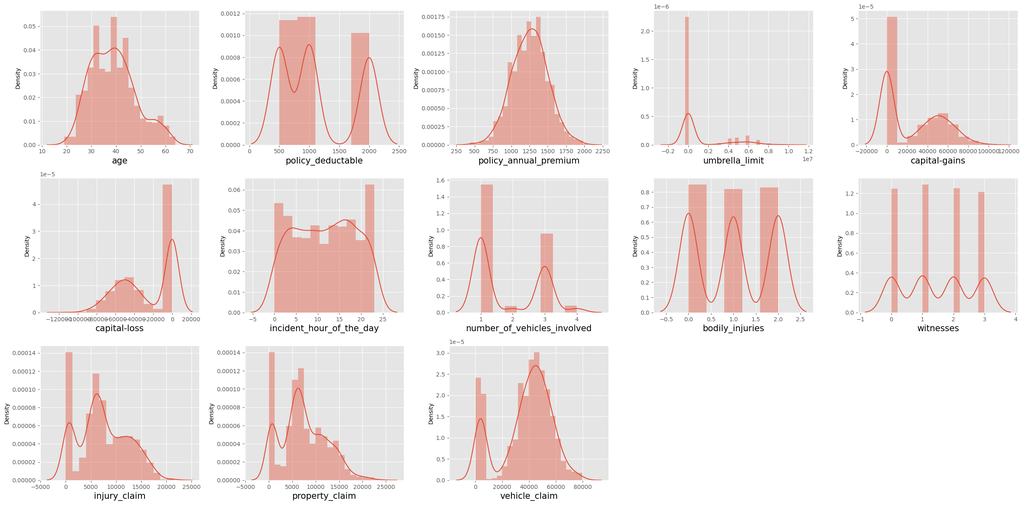

```python
plt.figure(figsize=(25,20))
plotnumber = 1

for col in dataset_numerical.columns:
    if plotnumber <= 13:
        ax = plt.subplot(5, 5, plotnumber)
        sns.distplot(dataset_numerical[col])
        plt.xlabel(col, fontsize = 15)
    plotnumber  += 1
plt.tight_layout()
plt.show()
```

Better visual of the outliers

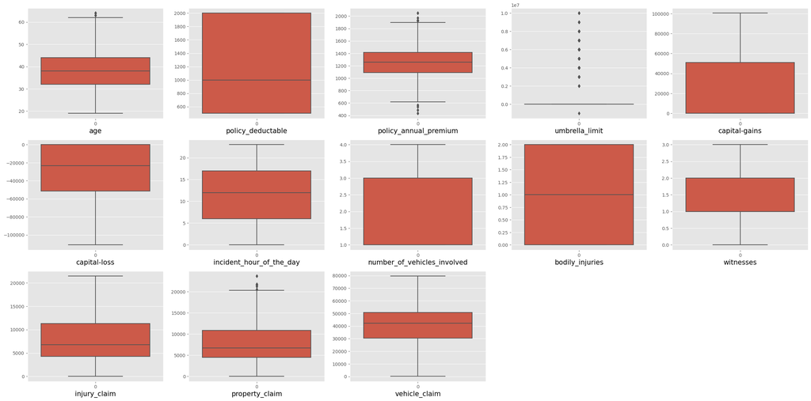

```python
plt.figure(figsize=(25,20))
plotnumber = 1

for col in dataset_numerical.columns:
    if plotnumber <= 13:
        ax = plt.subplot(5, 5, plotnumber)
        sns.boxplot(dataset_numerical[col])
        plt.xlabel(col, fontsize = 15)
    plotnumber  += 1
plt.tight_layout()
plt.show()
```

### 2.6.4 Removing Outliers using IQR

```python
dataset_clean = dataset.copy()
```

```python
dataset_numerical.columns
```

```
Index(['age', 'policy_deductable', 'policy_annual_premium', 'umbrella_limit',
       'capital-gains', 'capital-loss', 'incident_hour_of_the_day',
       'number_of_vehicles_involved', 'bodily_injuries', 'witnesses',
       'injury_claim', 'property_claim', 'vehicle_claim'],
      dtype='object')
```

```python
numerical_columns = list(dataset_numerical.columns)
q1 = dataset_clean[numerical_columns].quantile(0.25) # lower quartile
q3 = dataset_clean[numerical_columns].quantile(0.75) # upper quartile
iqr = q3 - q1 # interquartile range
lb = q1 - 1.5*iqr # lower booundary
hb = q3 + 1.5*iqr # higher boundary
for i in numerical_columns:
    dataset_clean = dataset_clean[(dataset_clean[i]>=lb[i]) & (dataset_clean[i]<=hb[i])]
dataset_clean.head()
```

|  | age | policy_csl | policy_deductable | policy_annual_premium | umbrella_limit | insured_sex | insured_education_level | insured_occupation | insured_relationship | capital-gains | ... | incident_hour_of_the_day | number_of_vehicles_involved | property_damage | bodily_injuries | witnesses | police_report_available | injury_claim | property_claim | vehicle_claim | fraud_reported |
| --- | --- | --- | --- | --- | --- | --- | --- | --- | --- | --- | --- | --- | --- | --- | --- | --- | --- | --- | --- | --- | --- |
| 0 | 48 | 250/500 | 1000 | 1406.91 | 0 | MALE | MD | craft-repair | husband | 53300 | ... | 5 | 1 | YES | 1 | 2 | YES | 6510 | 13020 | 52080 | Y |
| 5 | 39 | 250/500 | 1000 | 1351.10 | 0 | FEMALE | PhD | tech-support | unmarried | 0 | ... | 19 | 3 | NO | 0 | 2 | NO | 6410 | 6410 | 51280 | Y |
| 6 | 34 | 250/500 | 1000 | 1333.35 | 0 | MALE | PhD | prof-specialty | husband | 0 | ... | 0 | 3 | NO | 0 | 0 | NO | 21450 | 7150 | 50050 | N |
| 7 | 37 | 100/300 | 1000 | 1137.03 | 0 | MALE | Associate | tech-support | unmarried | 0 | ... | 23 | 3 | NO | 2 | 2 | YES | 9380 | 9380 | 32830 | N |
| 8 | 33 | 100/300 | 500 | 1442.99 | 0 | FEMALE | PhD | other-service | own-child | 0 | ... | 21 | 1 | NO | 1 | 1 | YES | 2770 | 2770 | 22160 | N |

5 rows × 25 columns

```python
dataset_clean.shape
```

```
(783, 25)
```

```python
print(f"Removing outliers made us lose {dataset.shape[0] - dataset_clean.shape[0]} samples from the dataset.")
```

```
Removing outliers made us lose 217 samples from the dataset.
```

```python
dataset_clean.head()
```

|  | age | policy_csl | policy_deductable | policy_annual_premium | umbrella_limit | insured_sex | insured_education_level | insured_occupation | insured_relationship | capital-gains | ... | incident_hour_of_the_day | number_of_vehicles_involved | property_damage | bodily_injuries | witnesses | police_report_available | injury_claim | property_claim | vehicle_claim | fraud_reported |
| --- | --- | --- | --- | --- | --- | --- | --- | --- | --- | --- | --- | --- | --- | --- | --- | --- | --- | --- | --- | --- | --- |
| 0 | 48 | 250/500 | 1000 | 1406.91 | 0 | MALE | MD | craft-repair | husband | 53300 | ... | 5 | 1 | YES | 1 | 2 | YES | 6510 | 13020 | 52080 | Y |
| 5 | 39 | 250/500 | 1000 | 1351.10 | 0 | FEMALE | PhD | tech-support | unmarried | 0 | ... | 19 | 3 | NO | 0 | 2 | NO | 6410 | 6410 | 51280 | Y |
| 6 | 34 | 250/500 | 1000 | 1333.35 | 0 | MALE | PhD | prof-specialty | husband | 0 | ... | 0 | 3 | NO | 0 | 0 | NO | 21450 | 7150 | 50050 | N |
| 7 | 37 | 100/300 | 1000 | 1137.03 | 0 | MALE | Associate | tech-support | unmarried | 0 | ... | 23 | 3 | NO | 2 | 2 | YES | 9380 | 9380 | 32830 | N |
| 8 | 33 | 100/300 | 500 | 1442.99 | 0 | FEMALE | PhD | other-service | own-child | 0 | ... | 21 | 1 | NO | 1 | 1 | YES | 2770 | 2770 | 22160 | N |

5 rows × 25 columns

```python
dataset_clean.info()
```

```
<class 'pandas.core.frame.DataFrame'>
Int64Index: 783 entries, 0 to 999
Data columns (total 25 columns):
 #   Column                       Non-Null Count  Dtype
---  ------                       --------------  -----
 0   age                          783 non-null    int64
 1   policy_csl                   783 non-null    object
 2   policy_deductable            783 non-null    int64
 3   policy_annual_premium        783 non-null    float64
 4   umbrella_limit               783 non-null    int64
 5   insured_sex                  783 non-null    object
 6   insured_education_level      783 non-null    object
 7   insured_occupation           783 non-null    object
 8   insured_relationship         783 non-null    object
 9   capital-gains                783 non-null    int64
```

[output cut: 17 more lines]

Seperating features and targets

```python
y = dataset_clean['fraud_reported']
X = dataset_clean.drop('fraud_reported', axis = 1)
```

```python
X.head()
X.shape
```

```
(783, 24)
```

```python
y.head()
y.shape
```

```
(783,)
```

#### Return back you target, when it's in form of 0 and 1 into the dataframe

```python
y.replace('Y',1, inplace = True)
```

```python
y.replace('N', 0, inplace = True)
```

```python
y.shape
```

```
(783,)
```

New numerical

```python
new_dataset_numerical =  X.select_dtypes(include = ['float64', 'int64'])
new_dataset_numerical
```

|  | age | policy_deductable | policy_annual_premium | umbrella_limit | capital-gains | capital-loss | incident_hour_of_the_day | number_of_vehicles_involved | bodily_injuries | witnesses | injury_claim | property_claim | vehicle_claim |
| --- | --- | --- | --- | --- | --- | --- | --- | --- | --- | --- | --- | --- | --- |
| 0 | 48 | 1000 | 1406.91 | 0 | 53300 | 0 | 5 | 1 | 1 | 2 | 6510 | 13020 | 52080 |
| 5 | 39 | 1000 | 1351.10 | 0 | 0 | 0 | 19 | 3 | 0 | 2 | 6410 | 6410 | 51280 |
| 6 | 34 | 1000 | 1333.35 | 0 | 0 | -77000 | 0 | 3 | 0 | 0 | 21450 | 7150 | 50050 |
| 7 | 37 | 1000 | 1137.03 | 0 | 0 | 0 | 23 | 3 | 2 | 2 | 9380 | 9380 | 32830 |
| 8 | 33 | 500 | 1442.99 | 0 | 0 | 0 | 21 | 1 | 1 | 1 | 2770 | 2770 | 22160 |
| ... | ... | ... | ... | ... | ... | ... | ... | ... | ... | ... | ... | ... | ... |
| 993 | 28 | 1000 | 1235.14 | 0 | 0 | -32100 | 20 | 3 | 0 | 1 | 6020 | 6020 | 48160 |
| 994 | 30 | 1000 | 1347.04 | 0 | 0 | -82100 | 6 | 1 | 1 | 2 | 540 | 1080 | 4860 |
| 995 | 38 | 1000 | 1310.80 | 0 | 0 | 0 | 20 | 1 | 0 | 1 | 17440 | 8720 | 61040 |
| 996 | 41 | 1000 | 1436.79 | 0 | 70900 | 0 | 23 | 1 | 2 | 3 | 18080 | 18080 | 72320 |
| 999 | 60 | 1000 | 766.19 | 0 | 0 | 0 | 6 | 1 | 0 | 3 | 460 | 920 | 3680 |

783 rows × 13 columns

### 2.6.5 Encoding categorical features/columns using One Hot Encoding

```python
dataset_categorical = X.select_dtypes(include = 'object')
dataset_categorical.head()
dataset_categorical.shape
```

```
(783, 11)
```

The reason why we are using one hot encoding is that we do not want our model to prioritize any feature values, as what happens in Label encoding. The disadvantage of this method is that, the result will be sparse dataframe(containing only 0 and 1 values)

```python
dataset_categorical_dummie = pd.get_dummies(dataset_categorical, drop_first = True)
dataset_categorical_dummie.columns
```

```
Index(['policy_csl_250/500', 'policy_csl_500/1000', 'insured_sex_MALE',
       'insured_education_level_College',
       'insured_education_level_High School', 'insured_education_level_JD',
       'insured_education_level_MD', 'insured_education_level_Masters',
       'insured_education_level_PhD', 'insured_occupation_armed-forces',
       'insured_occupation_craft-repair', 'insured_occupation_exec-managerial',
       'insured_occupation_farming-fishing',
       'insured_occupation_handlers-cleaners',
       'insured_occupation_machine-op-inspct',
       'insured_occupation_other-service',
       'insured_occupation_priv-house-serv',
       'insured_occupation_prof-specialty',
       'insured_occupation_protective-serv', 'insured_occupation_sales',
       'insured_occupation_tech-support',
       'insured_occupation_transport-moving',
       'insured_relationship_not-in-family',
       'insured_relationship_other-relative', 'insured_relationship_own-child',
       'insured_relationship_unmarried', 'insured_relationship_wife',
       'incident_type_Parked Car', 'incident_type_Single Vehicle Collision',
       'incident_type_Vehicle Theft', 'collision_type_Rear Collision',
       'collision_type_Side Collision', 'incident_severity_Minor Damage',
       'incident_severity_Total Loss', 'incident_severity_Trivial Damage',
       'authorities_contacted_Fire', 'authorities_contacted_None',
       'authorities_contacted_Other', 'authorities_contacted_Police',
       'property_damage_YES', 'police_report_available_YES'],
      dtype='object')
```

```python
dataset_categorical_dummie.shape
```

```
(783, 41)
```

#### Let's concatenate numerical and categorical datasets first, before scaling

```python
X = pd.concat([new_dataset_numerical, dataset_categorical_dummie], axis = 1)
X.shape
```

```
(783, 54)
```

### 2.6.6 Scaling the clean dataset

We always scale numerical dataset then concatenate the result with categorical.

```python
new_dataset_numerical.head()
```

|  | age | policy_deductable | policy_annual_premium | umbrella_limit | capital-gains | capital-loss | incident_hour_of_the_day | number_of_vehicles_involved | bodily_injuries | witnesses | injury_claim | property_claim | vehicle_claim |
| --- | --- | --- | --- | --- | --- | --- | --- | --- | --- | --- | --- | --- | --- |
| 0 | 48 | 1000 | 1406.91 | 0 | 53300 | 0 | 5 | 1 | 1 | 2 | 6510 | 13020 | 52080 |
| 5 | 39 | 1000 | 1351.10 | 0 | 0 | 0 | 19 | 3 | 0 | 2 | 6410 | 6410 | 51280 |
| 6 | 34 | 1000 | 1333.35 | 0 | 0 | -77000 | 0 | 3 | 0 | 0 | 21450 | 7150 | 50050 |
| 7 | 37 | 1000 | 1137.03 | 0 | 0 | 0 | 23 | 3 | 2 | 2 | 9380 | 9380 | 32830 |
| 8 | 33 | 500 | 1442.99 | 0 | 0 | 0 | 21 | 1 | 1 | 1 | 2770 | 2770 | 22160 |

```python
new_dataset_numerical.shape
```

```
(783, 13)
```

#### Let's try scaling without splitting the dataset

```python
X.columns
```

```
Index(['age', 'policy_deductable', 'policy_annual_premium', 'umbrella_limit',
       'capital-gains', 'capital-loss', 'incident_hour_of_the_day',
       'number_of_vehicles_involved', 'bodily_injuries', 'witnesses',
       'injury_claim', 'property_claim', 'vehicle_claim', 'policy_csl_250/500',
       'policy_csl_500/1000', 'insured_sex_MALE',
       'insured_education_level_College',
       'insured_education_level_High School', 'insured_education_level_JD',
       'insured_education_level_MD', 'insured_education_level_Masters',
       'insured_education_level_PhD', 'insured_occupation_armed-forces',
       'insured_occupation_craft-repair', 'insured_occupation_exec-managerial',
       'insured_occupation_farming-fishing',
       'insured_occupation_handlers-cleaners',
       'insured_occupation_machine-op-inspct',
       'insured_occupation_other-service',
       'insured_occupation_priv-house-serv',
       'insured_occupation_prof-specialty',
       'insured_occupation_protective-serv', 'insured_occupation_sales',
       'insured_occupation_tech-support',
       'insured_occupation_transport-moving',
       'insured_relationship_not-in-family',
       'insured_relationship_other-relative', 'insured_relationship_own-child',
       'insured_relationship_unmarried', 'insured_relationship_wife',
       'incident_type_Parked Car', 'incident_type_Single Vehicle Collision',
       'incident_type_Vehicle Theft', 'collision_type_Rear Collision',
       'collision_type_Side Collision', 'incident_severity_Minor Damage',
       'incident_severity_Total Loss', 'incident_severity_Trivial Damage',
       'authorities_contacted_Fire', 'authorities_contacted_None',
       'authorities_contacted_Other', 'authorities_contacted_Police',
       'property_damage_YES', 'police_report_available_YES'],
      dtype='object')
```

```python
dataset_numerical.columns
```

```
Index(['age', 'policy_deductable', 'policy_annual_premium', 'umbrella_limit',
       'capital-gains', 'capital-loss', 'incident_hour_of_the_day',
       'number_of_vehicles_involved', 'bodily_injuries', 'witnesses',
       'injury_claim', 'property_claim', 'vehicle_claim'],
      dtype='object')
```

```python
num_dataset = X[['age', 'policy_deductable', 'policy_annual_premium', 'umbrella_limit',
       'capital-gains', 'capital-loss', 'incident_hour_of_the_day',
       'number_of_vehicles_involved', 'bodily_injuries', 'witnesses',
       'injury_claim', 'property_claim', 'vehicle_claim']]
```

```python
from sklearn.preprocessing import StandardScaler
```

```python
scaler = StandardScaler()
scaled_data = scaler.fit_transform(num_dataset)
```

```python
scaled_num_dataset = pd.DataFrame(data = scaled_data, columns = num_dataset.columns,
                                 index = X.index)
scaled_num_dataset.head()
```

|  | age | policy_deductable | policy_annual_premium | umbrella_limit | capital-gains | capital-loss | incident_hour_of_the_day | number_of_vehicles_involved | bodily_injuries | witnesses | injury_claim | property_claim | vehicle_claim |
| --- | --- | --- | --- | --- | --- | --- | --- | --- | --- | --- | --- | --- | --- |
| 0 | 1.009948 | -0.236448 | 0.623608 | 0.0 | 0.974841 | 0.950761 | -0.969967 | -0.839620 | 0.036034 | 0.46001 | -0.210106 | 1.204848 | 0.742220 |
| 5 | 0.006408 | -0.236448 | 0.390877 | 0.0 | -0.913587 | 0.950761 | 1.053012 | 1.114087 | -1.190682 | 0.46001 | -0.230444 | -0.199322 | 0.699612 |
| 6 | -0.551114 | -0.236448 | 0.316859 | 0.0 | -0.913587 | -1.793496 | -1.692459 | 1.114087 | -1.190682 | -1.34093 | 2.828409 | -0.042123 | 0.634103 |
| 7 | -0.216600 | -0.236448 | -0.501805 | 0.0 | -0.913587 | 0.950761 | 1.631006 | 1.114087 | 1.262749 | 0.46001 | 0.373598 | 0.431599 | -0.283032 |
| 8 | -0.662618 | -1.055645 | 0.774064 | 0.0 | -0.913587 | 0.950761 | 1.342009 | -0.839620 | 0.036034 | -0.44046 | -0.970752 | -0.972571 | -0.851315 |

```python
scaled_num_dataset.shape
```

```
(783, 13)
```

#### Kindly note that this is strictly numerical dataset.

```python
X.drop(columns = scaled_num_dataset.columns, inplace = True)
# This has dropped all dataset that has been sclaed. That is it has dropped numerical
# dataset leaving categorical dataset.
```

```python
X.head()
```

|  | policy_csl_250/500 | policy_csl_500/1000 | insured_sex_MALE | insured_education_level_College | insured_education_level_High School | insured_education_level_JD | insured_education_level_MD | insured_education_level_Masters | insured_education_level_PhD | insured_occupation_armed-forces | ... | collision_type_Side Collision | incident_severity_Minor Damage | incident_severity_Total Loss | incident_severity_Trivial Damage | authorities_contacted_Fire | authorities_contacted_None | authorities_contacted_Other | authorities_contacted_Police | property_damage_YES | police_report_available_YES |
| --- | --- | --- | --- | --- | --- | --- | --- | --- | --- | --- | --- | --- | --- | --- | --- | --- | --- | --- | --- | --- | --- |
| 0 | 1 | 0 | 1 | 0 | 0 | 0 | 1 | 0 | 0 | 0 | ... | 1 | 0 | 0 | 0 | 0 | 0 | 0 | 1 | 1 | 1 |
| 5 | 1 | 0 | 0 | 0 | 0 | 0 | 0 | 0 | 1 | 0 | ... | 0 | 0 | 0 | 0 | 1 | 0 | 0 | 0 | 0 | 0 |
| 6 | 1 | 0 | 1 | 0 | 0 | 0 | 0 | 0 | 1 | 0 | ... | 0 | 1 | 0 | 0 | 0 | 0 | 0 | 1 | 0 | 0 |
| 7 | 0 | 0 | 1 | 0 | 0 | 0 | 0 | 0 | 0 | 0 | ... | 0 | 0 | 1 | 0 | 0 | 0 | 0 | 1 | 0 | 1 |
| 8 | 0 | 0 | 0 | 0 | 0 | 0 | 0 | 0 | 1 | 0 | ... | 0 | 0 | 1 | 0 | 0 | 0 | 0 | 1 | 0 | 1 |

5 rows × 41 columns

```python
X = pd.concat([scaled_num_dataset, X], axis = 1)
```

```python
X.shape
```

```
(783, 54)
```

```python
X.head()
```

|  | age | policy_deductable | policy_annual_premium | umbrella_limit | capital-gains | capital-loss | incident_hour_of_the_day | number_of_vehicles_involved | bodily_injuries | witnesses | ... | collision_type_Side Collision | incident_severity_Minor Damage | incident_severity_Total Loss | incident_severity_Trivial Damage | authorities_contacted_Fire | authorities_contacted_None | authorities_contacted_Other | authorities_contacted_Police | property_damage_YES | police_report_available_YES |
| --- | --- | --- | --- | --- | --- | --- | --- | --- | --- | --- | --- | --- | --- | --- | --- | --- | --- | --- | --- | --- | --- |
| 0 | 1.009948 | -0.236448 | 0.623608 | 0.0 | 0.974841 | 0.950761 | -0.969967 | -0.839620 | 0.036034 | 0.46001 | ... | 1 | 0 | 0 | 0 | 0 | 0 | 0 | 1 | 1 | 1 |
| 5 | 0.006408 | -0.236448 | 0.390877 | 0.0 | -0.913587 | 0.950761 | 1.053012 | 1.114087 | -1.190682 | 0.46001 | ... | 0 | 0 | 0 | 0 | 1 | 0 | 0 | 0 | 0 | 0 |
| 6 | -0.551114 | -0.236448 | 0.316859 | 0.0 | -0.913587 | -1.793496 | -1.692459 | 1.114087 | -1.190682 | -1.34093 | ... | 0 | 1 | 0 | 0 | 0 | 0 | 0 | 1 | 0 | 0 |
| 7 | -0.216600 | -0.236448 | -0.501805 | 0.0 | -0.913587 | 0.950761 | 1.631006 | 1.114087 | 1.262749 | 0.46001 | ... | 0 | 0 | 1 | 0 | 0 | 0 | 0 | 1 | 0 | 1 |
| 8 | -0.662618 | -1.055645 | 0.774064 | 0.0 | -0.913587 | 0.950761 | 1.342009 | -0.839620 | 0.036034 | -0.44046 | ... | 0 | 0 | 1 | 0 | 0 | 0 | 0 | 1 | 0 | 1 |

5 rows × 54 columns

```python
y.shape
```

```
(783,)
```

### 2.6.7 Dealing with imbalanced data

#### We start by splitting dataset into training & testing set

```python
from sklearn.model_selection import train_test_split
X_train, X_test, y_train, y_test = train_test_split(X, y, test_size = 0.2)
```

```python
X_train.shape
```

```
(626, 54)
```

```python
y_train.shape
```

```
(626,)
```

```python
X_test.shape
```

```
(157, 54)
```

```python
y_test.shape
```

```
(157,)
```

```python
from imblearn.over_sampling import SMOTE
sm = SMOTE(sampling_strategy = 0.5)
X_train, y_train = sm.fit_resample(X_train, y_train)
```

```python
X.shape
```

```
(783, 54)
```

```python
y.shape
```

```
(783,)
```

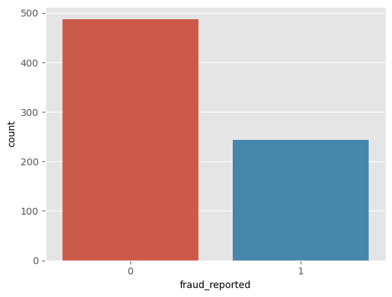

```python
sns.countplot(x = y_train)
plt.show()
```

#### We looked at y_train, because imbalancing focusses on the training target

## 3.0 Machine Learning Models

### 3.1 Support Vector Machine

```python
from sklearn.svm import SVC
from sklearn.model_selection import GridSearchCV
from sklearn.metrics import ConfusionMatrixDisplay
from sklearn.metrics import accuracy_score, confusion_matrix, classification_report

# Here we are instantiating the classifier
svc = SVC()

# Here, we are training the model
svc.fit(X_train, y_train)

# Prediction
y_pred = svc.predict(X_test)
```

Accuracy_score, confusion_matrix and classification_report

```python
svc_train_acc = accuracy_score(y_train, svc.predict(X_train))
svc_test_acc = accuracy_score(y_test, y_pred)

print(f"Trainig accuracy of Support Vector Classifier is : {svc_train_acc}")
print(f"Test accuracy of Support Vector Classifier is : {svc_test_acc}")

print(confusion_matrix(y_test, y_pred))
print(classification_report(y_test, y_pred))
```

```
Trainig accuracy of Support Vector Classifier is : 0.9207650273224044
Test accuracy of Support Vector Classifier is : 0.7579617834394905
[[107   6]
 [ 32  12]]
              precision    recall  f1-score   support

           0       0.77      0.95      0.85       113
           1       0.67      0.27      0.39        44

    accuracy                           0.76       157
   macro avg       0.72      0.61      0.62       157
weighted avg       0.74      0.76      0.72       157
```

```
Plotting a Confussion Matrix with sklearn
```

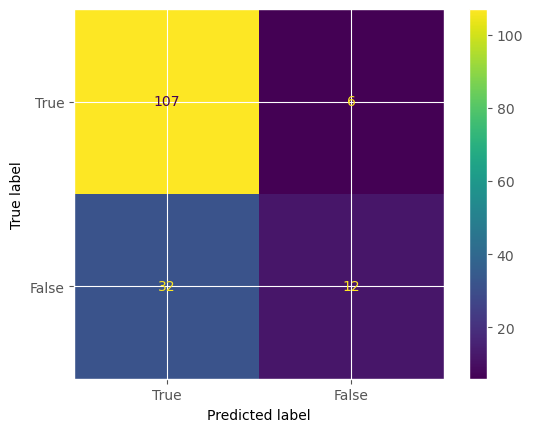

```python
print("Plotting a Confussion Matrix with sklearn")

conf_matrix = confusion_matrix(y_test, y_pred)
vis = ConfusionMatrixDisplay(confusion_matrix = conf_matrix, display_labels = ['True', 'False'])

vis.plot()
plt.show()
```

```python
#  defining parameter range
param_grid = {'C' : [0.1, 1, 10, 100, 1000],
             'gamma' : [1, 0.1, 0.01, 0.001, 0.0001],
             'kernel' : ['rbf']}

grid = GridSearchCV(SVC(), param_grid, refit = True, verbose = 3)

# fitting the model for grid search
grid.fit(X_train, y_train)
```

[output not shown]

[output cut: 71 more lines]

[output not shown]

```
GridSearchCV(estimator=SVC(),
             param_grid={'C': [0.1, 1, 10, 100, 1000],
                         'gamma': [1, 0.1, 0.01, 0.001, 0.0001],
                         'kernel': ['rbf']},
             verbose=3)
```

```python
# printing the best parameter after tuning
print(grid.best_params_)

# print how our model looks after hyper-parameter tuning
print(grid.best_estimator_)
```

```
{'C': 10, 'gamma': 0.1, 'kernel': 'rbf'}
SVC(C=10, gamma=0.1)
```

```python
y_pred = grid.predict(X_test)
```

After tuning the hyper-paramaters. Let's check accuracy_score, confusion_matrix and classification_report

```python
svc_train_acc = accuracy_score(y_train, svc.predict(X_train))
svc_test_acc = accuracy_score(y_test, y_pred)

print(f"Trainig accuracy of Support Vector Classifier is : {svc_train_acc}")
print(f"Test accuracy of Support Vector Classifier is : {svc_test_acc}")

print(confusion_matrix(y_test, y_pred))
print(classification_report(y_test, y_pred))
```

```
Trainig accuracy of Support Vector Classifier is : 0.9207650273224044
Test accuracy of Support Vector Classifier is : 0.7515923566878981
[[109   4]
 [ 35   9]]
              precision    recall  f1-score   support

           0       0.76      0.96      0.85       113
           1       0.69      0.20      0.32        44

    accuracy                           0.75       157
   macro avg       0.72      0.58      0.58       157
weighted avg       0.74      0.75      0.70       157
```

```
Plotting a Confussion Matrix with sklearn
```

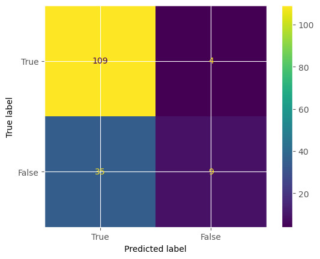

```python
print("Plotting a Confussion Matrix with sklearn")

conf_matrix = confusion_matrix(y_test, y_pred)
vis = ConfusionMatrixDisplay(confusion_matrix = conf_matrix, display_labels = ['True', 'False'])

vis.plot()
plt.show()
```

#### There is no much change in the confussion matrix.

### 3.2 KNN

```python
from sklearn.neighbors import KNeighborsClassifier

knn = KNeighborsClassifier(n_neighbors = 30) # instantiating the model
knn.fit(X_train, y_train) # training the model

y_pred = knn.predict(X_test) # using the model for prediction
```

Accuracy_score, confusion_matrix and classification_report

```python
knn_train_acc = accuracy_score(y_train, knn.predict(X_train))
knn_test_acc = accuracy_score(y_test, y_pred)

print(f"Training accuracy of KNN is : {knn_train_acc}")
print(f"Test accuracy of KNN is : {knn_test_acc}")

print(confusion_matrix(y_test, y_pred))
print(classification_report(y_test, y_pred))
```

```
Training accuracy of KNN is : 0.6871584699453552
Test accuracy of KNN is : 0.6624203821656051
[[81 32]
 [21 23]]
              precision    recall  f1-score   support

           0       0.79      0.72      0.75       113
           1       0.42      0.52      0.46        44

    accuracy                           0.66       157
   macro avg       0.61      0.62      0.61       157
weighted avg       0.69      0.66      0.67       157
```

```
Plotting a Confussion Matrix with sklearn
```

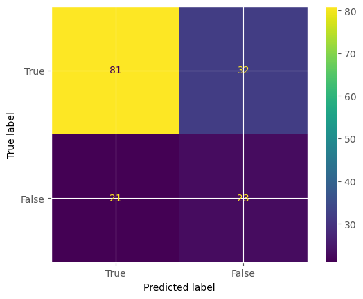

```python
print("Plotting a Confussion Matrix with sklearn")

conf_matrix = confusion_matrix(y_test, y_pred)
vis = ConfusionMatrixDisplay(confusion_matrix = conf_matrix, display_labels = ["True", "False"])

vis.plot()
plt.show()
```

#### Type 1 (False Positive): Error is evidenced here. Let's try hyperparameter tuning

```python
grid_params = {'n_neighbors' : [5,7,9,11,13,15],
              'weights' : ['uniform', 'distance'],
              'metric' : ['minkowski', 'euclidean', 'manhattan']}

grid = GridSearchCV(KNeighborsClassifier(), grid_params, verbose = 1, cv = 3,
                   n_jobs = -1)

# fitting the model on our training set
g_res = grid.fit(X_train, y_train)
```

```
Fitting 3 folds for each of 36 candidates, totalling 108 fits
```

```python
# find the best score
print("The best score is {}".format(g_res.best_score_))
print()
print("The hyper-parameters are:")
print(g_res.best_params_)
```

```
The best score is 0.6830601092896176

The hyper-parameters are:
{'metric': 'manhattan', 'n_neighbors': 5, 'weights': 'distance'}
```

```python
# Use the best parameters in the model
knn = KNeighborsClassifier(n_neighbors = 5, metric = 'manhattan', algorithm = 'brute',
                           weights = 'distance')

knn.fit(X_train, y_train)
```

```
KNeighborsClassifier(algorithm='brute', metric='manhattan', weights='distance')
```

```python
# get prediction
y_hat = knn.predict(X_train)
y_pred = knn.predict(X_test)
```

After tuning the hyper-paramaters, we can evaluate the model

```python
knn_train_acc = accuracy_score(y_train, y_hat)
knn_test_acc = accuracy_score(y_test, y_pred)

print(f"Training accuracy of KNN is : {knn_train_acc}")
print(f"Test accuracy of KNN is : {knn_test_acc}")

print(confusion_matrix(y_test, y_pred))
print(classification_report(y_test, y_pred))
```

```
Training accuracy of KNN is : 1.0
Test accuracy of KNN is : 0.6305732484076433
[[70 43]
 [15 29]]
              precision    recall  f1-score   support

           0       0.82      0.62      0.71       113
           1       0.40      0.66      0.50        44

    accuracy                           0.63       157
   macro avg       0.61      0.64      0.60       157
weighted avg       0.71      0.63      0.65       157
```

```
Plotting a Confussion Matrix with sklearn
```

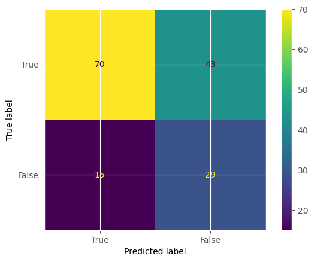

```python
print("Plotting a Confussion Matrix with sklearn")

conf_matrix = confusion_matrix(y_test, y_pred)
vis = ConfusionMatrixDisplay(confusion_matrix = conf_matrix, display_labels = ["True", "False"])

vis.plot()
plt.show()
```

#### There is no much change in the confusion matrix

### 3.3 Decision Tree Classifier

```python
from sklearn.tree import DecisionTreeClassifier

dtc =  DecisionTreeClassifier() # instantiating the class
dtc.fit(X_train, y_train) # Here, we are training the model

y_pred = dtc.predict(X_test) # Here, we are using the model for predictions
```

Accuracy_score, confusion_matrix and classification_report

```python
dtc_train_acc = accuracy_score(y_train, dtc.predict(X_train))
dtc_test_score = accuracy_score(y_test, y_pred)

print(f"Training accuracy of Decision Tree is : {dtc_train_acc}")
print(f"Test accuracy of Decision Tree is : {dtc_test_score}")

print(confusion_matrix(y_test, y_pred))
print(classification_report(y_test, y_pred))
```

```
Training accuracy of Decision Tree is : 1.0
Test accuracy of Decision Tree is : 0.7707006369426752
[[98 15]
 [21 23]]
              precision    recall  f1-score   support

           0       0.82      0.87      0.84       113
           1       0.61      0.52      0.56        44

    accuracy                           0.77       157
   macro avg       0.71      0.69      0.70       157
weighted avg       0.76      0.77      0.77       157
```

```
Plotting a Confussion Matrix with sklearn
```

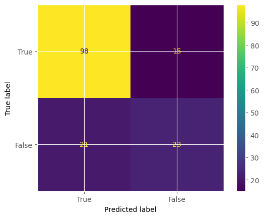

```python
print("Plotting a Confussion Matrix with sklearn")

conf_matrix = confusion_matrix(y_test, y_pred)
vis = ConfusionMatrixDisplay(confusion_matrix = conf_matrix, display_labels = ["True", "False"])

vis.plot()
plt.show()
```

#### Hyperparameter tuning

```python
# from sklearn.model_selection import GridSearchCV

grid_params = {
    'criterion' : ['gini', 'entropy'],
    'max_depth' : [3, 5, 7, 10],
    'min_samples_split' : range(2, 10, 1),
    'min_samples_leaf' : range(2, 10, 1)
}

grid_search = GridSearchCV(dtc, grid_params, cv = 5, n_jobs = -1, verbose = 1)
grid_search.fit(X_train, y_train)
```

```
Fitting 5 folds for each of 512 candidates, totalling 2560 fits
```

```
GridSearchCV(cv=5, estimator=DecisionTreeClassifier(), n_jobs=-1,
             param_grid={'criterion': ['gini', 'entropy'],
                         'max_depth': [3, 5, 7, 10],
                         'min_samples_leaf': range(2, 10),
                         'min_samples_split': range(2, 10)},
             verbose=1)
```

```python
# Best parameters and best score
print(grid_search.best_params_)
print(grid_search.best_score_)
```

```
{'criterion': 'gini', 'max_depth': 3, 'min_samples_leaf': 2, 'min_samples_split': 5}
0.8362128413009039
```

```python
# Best estimator
dtc = grid_search.best_estimator_
y_pred = dtc.predict(X_test)
```

#### After hyperparamater tuning. We testing accuracy_score, confusion_matrix and classification_report

```python
dtc_train_acc = accuracy_score(y_train, dtc.predict(X_train))
dtc_test_acc = accuracy_score(y_test, y_pred)

print(f"Training accuracy of Decision Tree is : {dtc_train_acc}")
print(f"Test accuracy of Decision Tree is : {dtc_test_acc}")

print(confusion_matrix(y_test, y_pred))
print(classification_report(y_test, y_pred))
```

```
Training accuracy of Decision Tree is : 0.8360655737704918
Test accuracy of Decision Tree is : 0.7961783439490446
[[93 20]
 [12 32]]
              precision    recall  f1-score   support

           0       0.89      0.82      0.85       113
           1       0.62      0.73      0.67        44

    accuracy                           0.80       157
   macro avg       0.75      0.78      0.76       157
weighted avg       0.81      0.80      0.80       157
```

```
Plotting a Confussion Matrix with sklearn
```

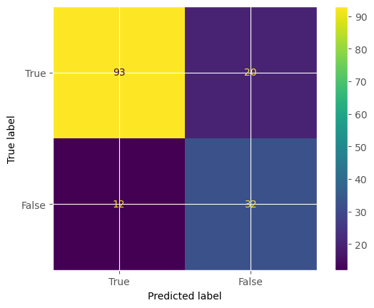

```python
print("Plotting a Confussion Matrix with sklearn")

conf_matrix = confusion_matrix(y_test, y_pred)
vis = ConfusionMatrixDisplay(confusion_matrix = conf_matrix, display_labels = ["True", "False"])

vis.plot()
plt.show()
```

### There is a slight improvement

### 3.4 Random Forest Classifier

```python
from sklearn.ensemble import RandomForestClassifier

# Instantiating the class of random forest
rand_clf = RandomForestClassifier()

# We train the model using fit method
rand_clf.fit(X_train, y_train)

# Prediction
y_pred = rand_clf.predict(X_test)
```

accuracy_score, confusion_matrix & classification_report

```python
rand_clf_train_acc = accuracy_score(y_train, rand_clf.predict(X_train))
rand_clf_test_acc = accuracy_score(y_test, y_pred)

print(f"Training accuracy of Decision Tree is : {rand_clf_train_acc}")
print(f"Test accuracy of Decision Tree is : {rand_clf_test_acc}")

print(confusion_matrix(y_test, y_pred))
print(classification_report(y_test, y_pred))
```

```
Training accuracy of Decision Tree is : 1.0
Test accuracy of Decision Tree is : 0.732484076433121
[[103  10]
 [ 32  12]]
              precision    recall  f1-score   support

           0       0.76      0.91      0.83       113
           1       0.55      0.27      0.36        44

    accuracy                           0.73       157
   macro avg       0.65      0.59      0.60       157
weighted avg       0.70      0.73      0.70       157
```

```
Plotting a Confussion Matrix with sklearn
```

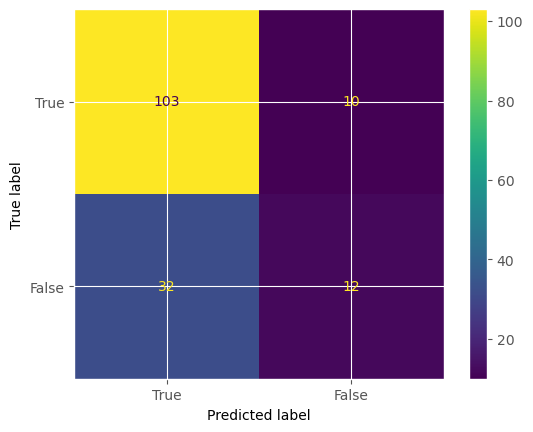

```python
print("Plotting a Confussion Matrix with sklearn")

conf_matrix = confusion_matrix(y_test, y_pred)
vis = ConfusionMatrixDisplay(confusion_matrix = conf_matrix, display_labels = ["True", "False"])

vis.plot()
plt.show()
```

#### Hyperparamater Tuning - GridSearchCV

```python
# Create the paramater grid based on the results of random search
param_grid = {
    'n_estimators' : [25, 50, 100, 150],
    'max_features' : ['sqrt', 'log2', None],
    'max_depth' : [3, 6, 9],
    'max_leaf_nodes' : [3, 6, 9],

}

# instantiating the grid search model
grid_search = GridSearchCV(estimator = RandomForestClassifier(), param_grid = param_grid)
grid_search.fit(X_test, y_test)
print(grid_search.best_estimator_)
```

```
RandomForestClassifier(max_depth=6, max_features=None, max_leaf_nodes=9)
```

```python
rand_clf = RandomForestClassifier(max_depth=6,
                                    max_features='log2',
                                    max_leaf_nodes=9,
                                    n_estimators=25)

rand_clf.fit(X_test, y_test)
y_pred = rand_clf.predict(X_test)
```

Evaluation after hyperparamater tuning

```python
rand_clf_train_acc = accuracy_score(y_train, rand_clf.predict(X_train))
rand_clf_test_acc = accuracy_score(y_test, y_pred)

print(f"Training accuracy of Decision Tree is : {rand_clf_train_acc}")
print(f"Test accuracy of Decision Tree is : {rand_clf_test_acc}")

print(confusion_matrix(y_test, y_pred))
print(classification_report(y_test, y_pred))
```

```
Training accuracy of Decision Tree is : 0.6666666666666666
Test accuracy of Decision Tree is : 0.8089171974522293
[[113   0]
 [ 30  14]]
              precision    recall  f1-score   support

           0       0.79      1.00      0.88       113
           1       1.00      0.32      0.48        44

    accuracy                           0.81       157
   macro avg       0.90      0.66      0.68       157
weighted avg       0.85      0.81      0.77       157
```

#### Hyperparameter Tuning - RandomizedSearchCV

```python
from sklearn.model_selection import RandomizedSearchCV
random_search = RandomizedSearchCV(RandomForestClassifier(),
                                   param_grid)
random_search.fit(X_train, y_train)
print(random_search.best_estimator_)
```

```
RandomForestClassifier(max_depth=9, max_features=None, max_leaf_nodes=6,
                       n_estimators=25)
```

```python
rand_clf = RandomForestClassifier(max_depth=3, max_features=None, max_leaf_nodes=6)

rand_clf.fit(X_test, y_test)
y_pred = rand_clf.predict(X_test)
```

Evaluation?

```python
rand_clf_train_acc = accuracy_score(y_train, rand_clf.predict(X_train))
rand_clf_test_acc = accuracy_score(y_test, y_pred)

print(f"Training accuracy of Decision Tree is : {rand_clf_train_acc}")
print(f"Test accuracy of Decision Tree is : {rand_clf_test_acc}")

print(confusion_matrix(y_test, y_pred))
print(classification_report(y_test, y_pred))
```

```
Training accuracy of Decision Tree is : 0.6871584699453552
Test accuracy of Decision Tree is : 0.8407643312101911
[[112   1]
 [ 24  20]]
              precision    recall  f1-score   support

           0       0.82      0.99      0.90       113
           1       0.95      0.45      0.62        44

    accuracy                           0.84       157
   macro avg       0.89      0.72      0.76       157
weighted avg       0.86      0.84      0.82       157
```